# Exercise 21

## Graph proportions vs vote-share

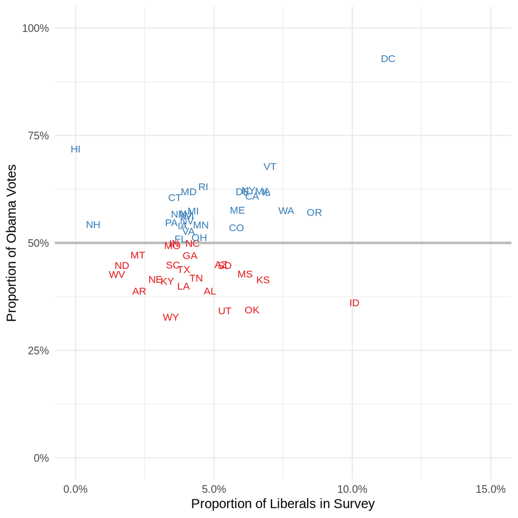

```r
d %>%
  ggplot(aes(x=lib.prop, y=obama_vote_share, label=abb, col=obama_won)) +
  geom_hline(yintercept = 0.5, col="grey", size=1) +
  geom_text(show.legend = F, size=3) +
  theme_minimal() +
  scale_color_brewer(palette="Set1") +
  scale_y_continuous(labels = percent,
                     name = "Proportion of Obama Votes",
                     limits = c(0,1)) +
  scale_x_continuous(labels = percent,
                     name = "Proportion of Liberals in Survey",
                     limits = c(0, 0.15) )
```

We see that some states had a high proportion of liberals in the survey but a low proportion of votes for Obama in the election.

## Graph Bayes posterior mean vs vote-share

The conjugate prior for the Poisson distribution is the Gamma distribution $\text{Gamma}(\alpha, \beta)$ with shape parameter $\alpha$ and rate parameter $\beta$. We can use the Method of Moments to obtain estimates for our prior:

```r
( rate <- mean( d$lib / d$n ) / var( d$lib / d$n ) )
```

```
[1] 103.8434
```

```r
( shape <- rate*mean( d$lib / d$n ) )
```

```
[1] 4.865153
```

```r
rate <- mean( d$lib / d$n ) / var( d$lib / d$n )
shape <- rate*mean( d$lib / d$n )
```

This gives a prior that puts most probability mass between 0 and 0.1 for the rate parameter $\theta$.

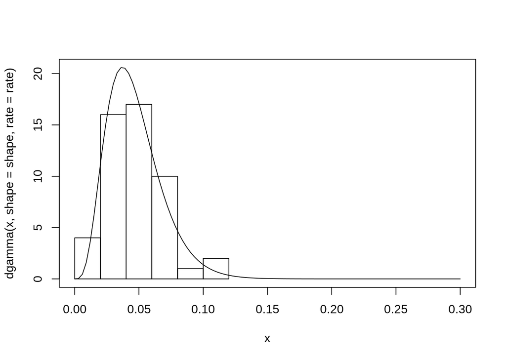

```r
curve(dgamma(x, shape=shape, rate=rate), from=0, to=0.3)
hist(d$lib / d$n , add=T)
```

The posterior for Gamma is then $\text{Gamma}(\alpha + \sum_i^n y_i, \beta + \sum_i^n x_i)$ from which we can estimate the posterior mean.

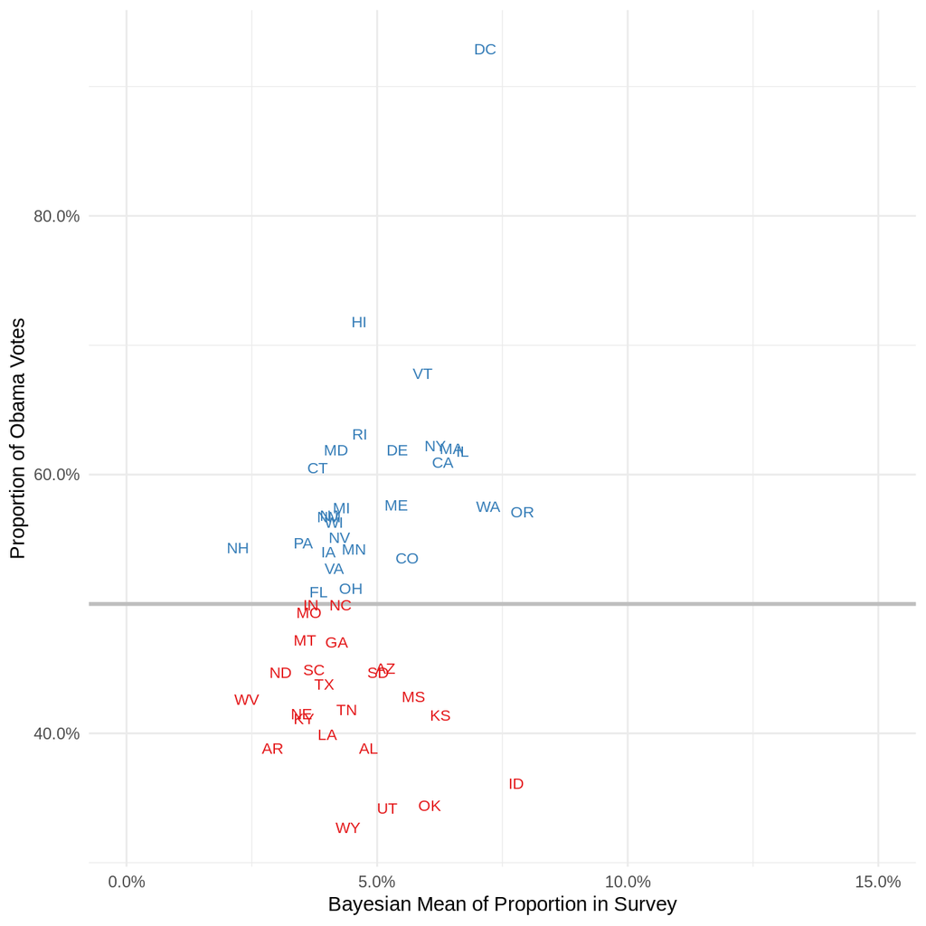

```r
d %>%
  mutate(post_shape = shape + lib,
         post_rate = rate + n,
         post_mean = post_shape / post_rate ) %>%
  ggplot(aes(y=obama_vote_share, x=post_mean, label=abb, col=obama_won)) +
  geom_hline(yintercept = 0.5, col="grey", size=1) +
  geom_text(show.legend = F, size=3) +
  theme_minimal() +
  scale_color_brewer(palette="Set1") +
  scale_y_continuous(labels = percent,
                     name = "Proportion of Obama Votes") +
  scale_x_continuous(labels = percent,
                     name = "Bayesian Mean of Proportion in Survey",
                     limits = c(0, 0.15) )
```

## Graph proportion vs number of survey-participants

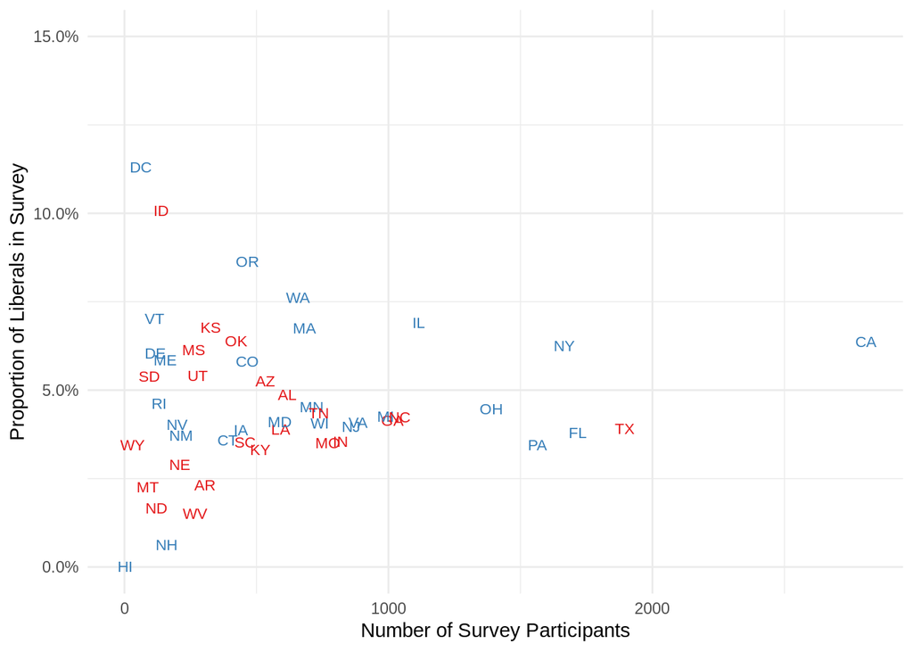

```r
d %>%
  ggplot(aes(x=n, y=lib.prop, label=abb, col=obama_won)) +
  geom_text(show.legend = F, size=3) +
  theme_minimal() +
  scale_color_brewer(palette="Set1") +
  scale_x_continuous(name = "Number of Survey Participants") +
  scale_y_continuous(labels = percent,
                     name ="Proportion of Liberals in Survey",
                     limits = c(0,0.15))
```

## Graph Bayesian estimate vs number of survey-participants

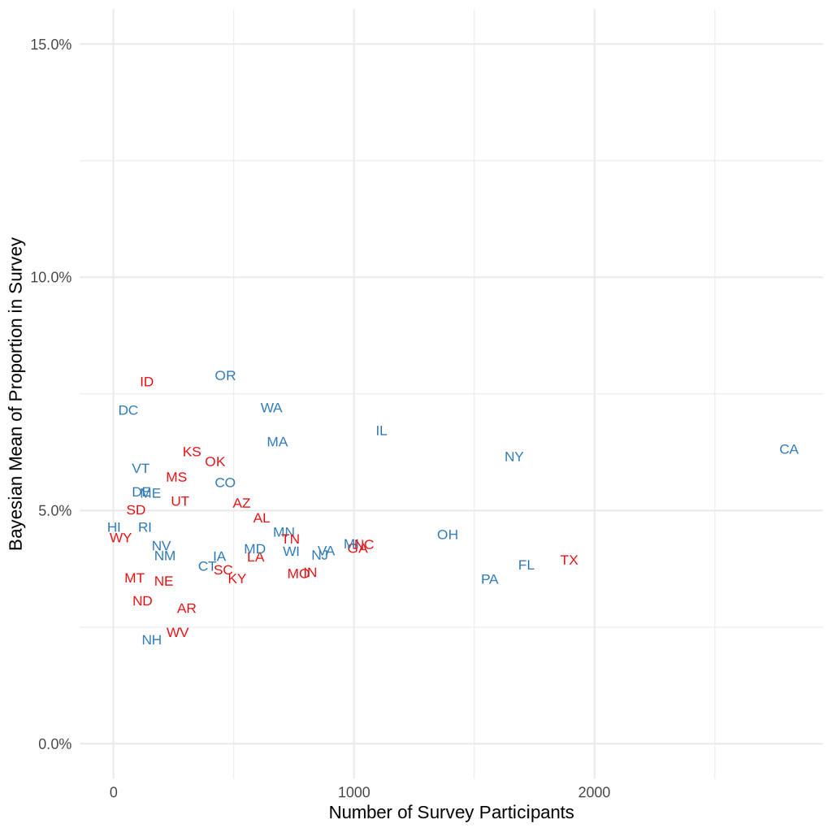

```r
d %>%
  mutate(post_shape = shape + lib,
         post_rate = rate + n,
         post_mean = post_shape / post_rate ) %>%
  ggplot(aes(x=n, y=post_mean, label=abb, col=obama_won)) +
  geom_text(show.legend = F, size=3) +
  theme_minimal() +
  scale_color_brewer(palette="Set1") +
  scale_x_continuous(name = "Number of Survey Participants") +
  scale_y_continuous(labels = percent,
                     name = "Bayesian Mean of Proportion in Survey",
                     limits = c(0, 0.15) )
```